# It’s not how much, but how well you exercise!

### Predict and Validate models

#### Predict and validate models against the training set itsef

- Using Bootstrap resampling technique

```r
predict_rpart_itself <- predict(trainedModel_rpart, training)
```

- Using 4 fold cross validation resampling technique

```r
predict_rf_itself <- predict(trainedModel_rf, training)
```

#### Calculate the misclassification rate of model validated against itself

- Using Bootstrap

```r
confMatrix_rpart_itself <-confusionMatrix(predict_rpart_itself, training$classe)
confMatrix_rpart_itself
```

```
## Confusion Matrix and Statistics
##
##           Reference
## Prediction    A    B    C    D    E
##          A 2401  383   62  120   36
##          B    7  485   50   16   13
##          C  770  462 1609  629  481
##          D  717 1328  675 1487  852
##          E   11    0    0    0 1143
##
## Overall Statistics
##
##                Accuracy : 0.519
##                  95% CI : (0.51, 0.527)
##     No Information Rate : 0.284
##     P-Value [Acc > NIR] : <0.0000000000000002
##
##                   Kappa : 0.401
##  Mcnemar's Test P-Value : <0.0000000000000002
##
## Statistics by Class:
##
##                      Class: A Class: B Class: C Class: D Class: E
## Sensitivity             0.615   0.1825    0.672    0.660   0.4527
## Specificity             0.939   0.9922    0.793    0.689   0.9990
## Pos Pred Value          0.800   0.8494    0.407    0.294   0.9905
## Neg Pred Value          0.860   0.8350    0.920    0.912   0.8902
## Prevalence              0.284   0.1935    0.174    0.164   0.1838
## Detection Rate          0.175   0.0353    0.117    0.108   0.0832
## Detection Prevalence    0.219   0.0416    0.288    0.368   0.0840
## Balanced Accuracy       0.777   0.5874    0.733    0.675   0.7258
```

- Using 4 fold cross validation

```r
confMatrix_rf_itself <-confusionMatrix(predict_rf_itself, training$classe)
confMatrix_rf_itself
```

```
## Confusion Matrix and Statistics
##
##           Reference
## Prediction    A    B    C    D    E
##          A 3906    0    0    0    0
##          B    0 2658    0    0    0
##          C    0    0 2396    0    0
##          D    0    0    0 2252    0
##          E    0    0    0    0 2525
##
## Overall Statistics
##
##                Accuracy : 1
##                  95% CI : (1, 1)
##     No Information Rate : 0.284
##     P-Value [Acc > NIR] : <0.0000000000000002
##
##                   Kappa : 1
##  Mcnemar's Test P-Value : NA
##
## Statistics by Class:
##
##                      Class: A Class: B Class: C Class: D Class: E
## Sensitivity             1.000    1.000    1.000    1.000    1.000
## Specificity             1.000    1.000    1.000    1.000    1.000
## Pos Pred Value          1.000    1.000    1.000    1.000    1.000
## Neg Pred Value          1.000    1.000    1.000    1.000    1.000
## Prevalence              0.284    0.193    0.174    0.164    0.184
## Detection Rate          0.284    0.193    0.174    0.164    0.184
## Detection Prevalence    0.284    0.193    0.174    0.164    0.184
## Balanced Accuracy       1.000    1.000    1.000    1.000    1.000
```

#### Calculate in-sample error rates of model validated against itself.

- Using Bootstrap

```r
inSampleError_rpart <- sum(predict_rpart_itself  != training$classe)/nrow(training)
inSampleError_rpart
```

```
## [1] 0.4813
```

- Using 4 fold cross validation

```r
inSampleError_rf <- sum(predict_rf_itself  != training$classe)/nrow(training)
inSampleError_rf
```

```
## [1] 0
```

#### Predict and validate random forest model against the cross validation set

- Using 4 fold cross validation

```r
predict_rf_validation <- predict(trainedModel_rf, validation)
```

- Calculate the misclassification/error rate for random forest model with validation data set using confusionMatrix function

```r
confMatrix_rf_validation <-confusionMatrix(predict_rf_validation, validation$classe)
confMatrix_rf_validation
```

```
## Confusion Matrix and Statistics
##
##           Reference
## Prediction    A    B    C    D    E
##          A 1671    8    0    0    0
##          B    3 1130    8    0    0
##          C    0    1 1016   18    0
##          D    0    0    2  945    4
##          E    0    0    0    1 1078
##
## Overall Statistics
##
##                Accuracy : 0.992
##                  95% CI : (0.99, 0.994)
##     No Information Rate : 0.284
##     P-Value [Acc > NIR] : <0.0000000000000002
##
##                   Kappa : 0.99
##  Mcnemar's Test P-Value : NA
##
## Statistics by Class:
##
##                      Class: A Class: B Class: C Class: D Class: E
## Sensitivity             0.998    0.992    0.990    0.980    0.996
## Specificity             0.998    0.998    0.996    0.999    1.000
## Pos Pred Value          0.995    0.990    0.982    0.994    0.999
## Neg Pred Value          0.999    0.998    0.998    0.996    0.999
## Prevalence              0.284    0.194    0.174    0.164    0.184
## Detection Rate          0.284    0.192    0.173    0.161    0.183
## Detection Prevalence    0.285    0.194    0.176    0.162    0.183
## Balanced Accuracy       0.998    0.995    0.993    0.990    0.998
```

- Calculate out of sample error rate for rf model

```r
outOfSampleError <- sum(predict_rf_validation  != validation$classe)/nrow(validation)
outOfSampleError
```

```
## [1] 0.007647
```

## Conclusion

A predictive model built using randomForest algorithm with 4 fold cross validation is able to predict *classe* outcome with almost 100% accuracy with high sensitivity and specivity.

## Appendix

### Figure 1. Random forest predictive model plot shows decrease in error rates as number of trees increase

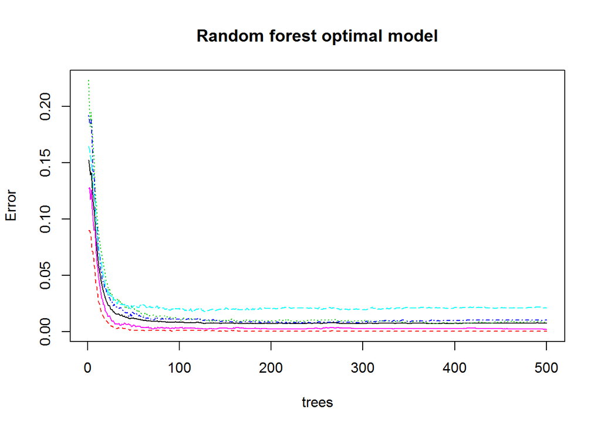

```r
finalModel <- trainedModel_rf$finalMode
plot(finalModel,main="Random forest optimal model")
```

### Figure 2. Random forest predictive model plot shows importance of various predictors

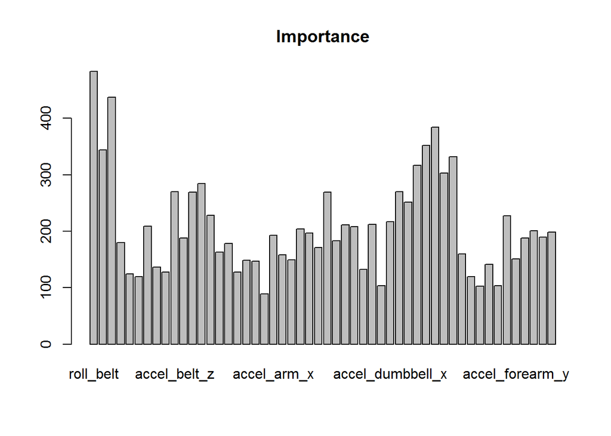

```r
barplot(finalModel$importance[, 1], main = "Importance")
```

### Testing the model

```r
pml_write_files = function(x){
  n = length(x)
  for(i in 1:n){
    filename = paste0("problem_id_",i,".txt")
    write.table(x[i],file=filename,quote=FALSE,row.names=FALSE,col.names=FALSE)
  }
}
answers  <- predict(trainedModel_rf, testingRaw)
pml_write_files(answers)
```